# Clase 15-01-2026

## Inyecciones SQL

[figure not shown]

Todo codigo se puede inyectar

[figure not shown]

Como funciona ?

[figure not shown]

[figure not shown]

ves ese OR 1 = 1

La consulta se convierte en

[figure not shown]

La condicion 1 = 1 es verdadera por lo que hace la consulta verdadera.

[figure not shown]

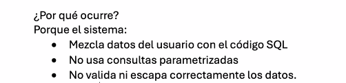

[figure not shown]

Viste aqui uso OR 1= 1

[figure not shown]

[figure not shown]

Herramientas DAST se usa para alertar y bloquear usuarios

cuando estan programando son SAST

## Clase 12 de Marzo

[figure not shown]

Como se ve creo hashes y los metio a una carpeta

[figure not shown]

Aqui con esto empieza a buscar dentro de la DB del worklist para poder decifrar si esta o no. Y lo guarda los resultados en un txt.

Hash cat es otro que pero no es tan sencillo.